# Лабораторная работа №7

Управление журналами событий в системе

Ришард Когенгар

Российский университет дружбы народов, Москва, Россия

20 января 2026

# Цель работы

## Основная цель

Получить навыки работы с журналами мониторинга различных событий в системе: - просмотр и анализ журналов - мониторинг в реальном времени - настройка rsyslog и journald

# Ход выполнения работы

## Ошибка аутентификации su

- В 3-й вкладке выполнен выход из root (Ctrl + d)
- Повторная попытка su с неверным паролем
- В журнале появляется сообщение вида FAILED SU (to root) username …
- Событие фиксируется в /var/log/messages

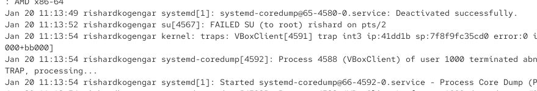

Ошибка аутентификации su фиксируется в журнале

## Регистрация сообщения через logger

- В 3-й вкладке из-под пользователя отправлено сообщение в журнал (logger hello)
- Во 2-й вкладке оно отображается сразу (режим реального времени)
- Сообщение также записывается в /var/log/messages

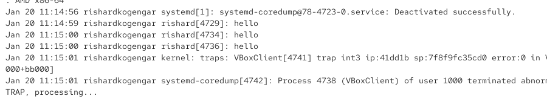

Сообщение logger в системном журнале

## Просмотр журнала безопасности /var/log/secure

- Остановлен мониторинг /var/log/messages (Ctrl + c)
- Просмотрены последние 20 строк журнала безопасности
- В журнале присутствуют записи об ошибке авторизации su

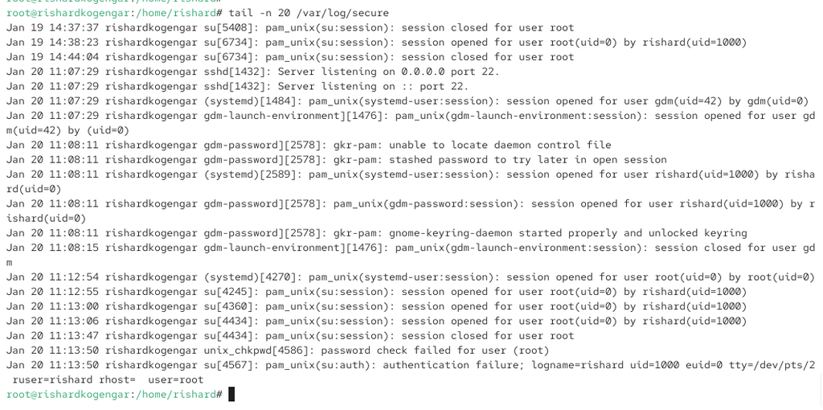

Просмотр /var/log/secure

## Установка и запуск Apache (httpd)

- Установлен пакет httpd
- Служба запущена и включена в автозагрузку
- Проверена корректность состояния службы

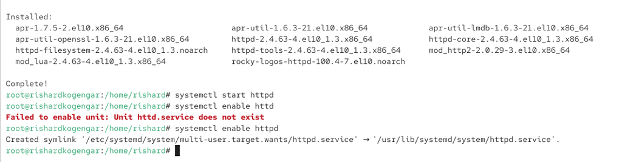

Установка и запуск Apache

## Просмотр журнала ошибок Apache

- Выполнен просмотр журнала /var/log/httpd/error_log
- Зафиксированы сообщения о запуске и работе httpd

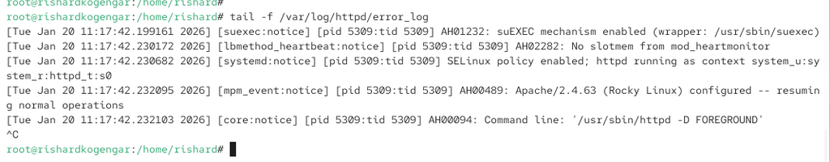

Журнал ошибок Apache

## Перенаправление ErrorLog в syslog

- Открыт файл /etc/httpd/conf/httpd.conf
- Добавлена строка ErrorLog syslog:local1
- Apache начинает отправлять сообщения в syslog с использованием local1

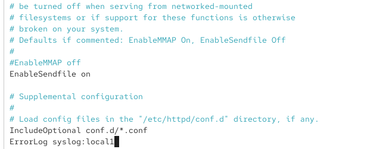

Изменение httpd.conf: ErrorLog syslog:local1

## Правило rsyslog для local1

- В /etc/rsyslog.d создан файл httpd.conf
- Добавлено правило: local1.* -> /var/log/httpd-error.log
- Это обеспечивает отдельный файл лога для сообщений httpd через syslog

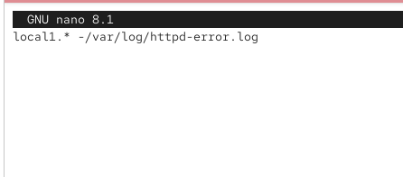

Правило rsyslog для Apache

## Настройка debug-логирования

- В /etc/rsyslog.d создан файл debug.conf
- Добавлено правило: *.debug -> /var/log/messages-debug
- Перезапущена служба rsyslog для применения правил

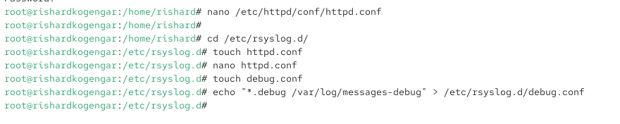

Создание debug.conf и настройка отладочного лога

## Проверка: сообщение daemon.debug

- Запущен мониторинг /var/log/messages-debug
- Отправлено тестовое сообщение уровня daemon.debug
- Сообщение отображается в отдельном отладочном журнале

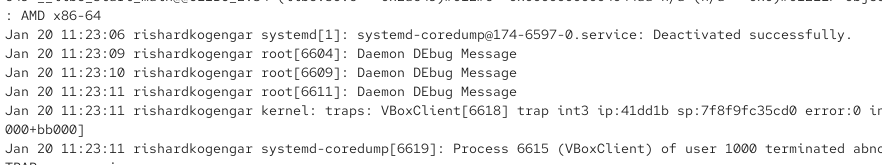

Проверка отладочного сообщения в messages-debug

## Просмотр журнала с момента загрузки системы

- Выполнен просмотр журнала journald за текущую загрузку
- Отображены сообщения ядра и системных служб

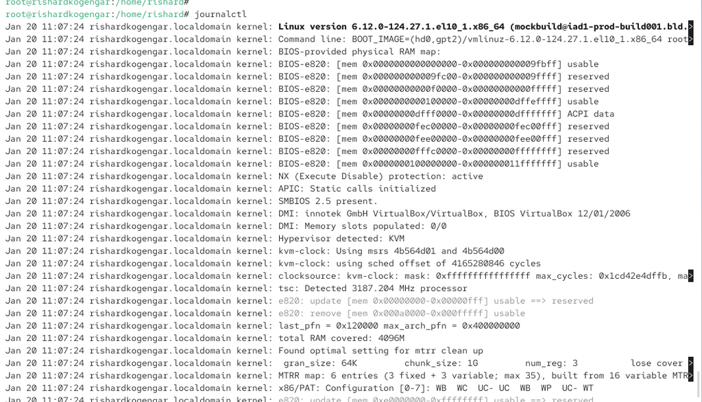

journalctl: журнал с момента загрузки

## Просмотр журнала без пейджера

- Выполнен вывод журнала без использования пейджера
- Удобно для перенаправления и быстрой обработки вывода

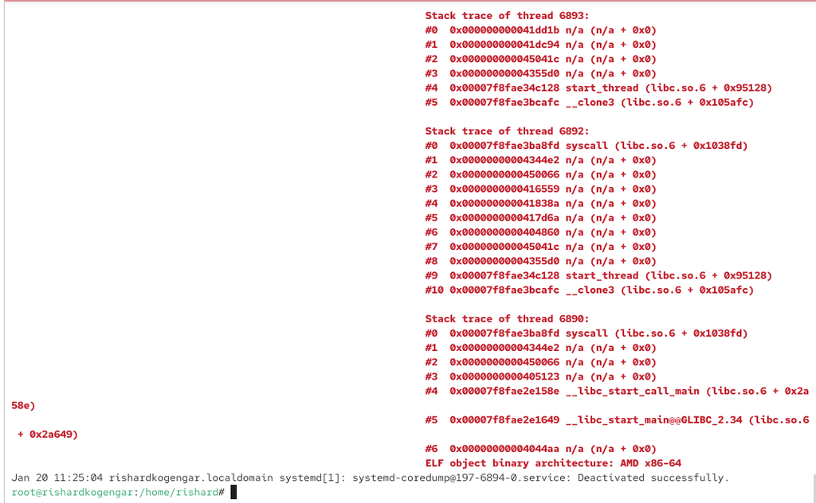

journalctl –no-pager

## Режим реального времени

- Включён режим слежения за журналом в реальном времени (journalctl -f)
- Просмотр остановлен вручную (Ctrl + c)

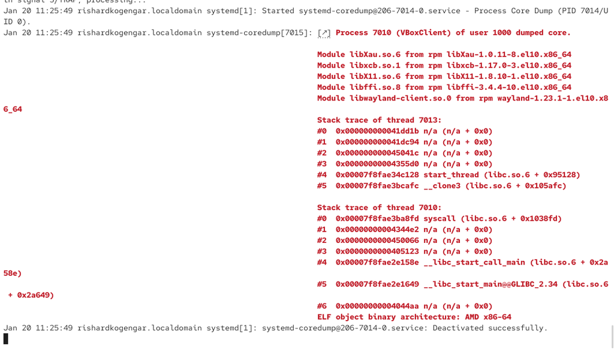

journalctl -f

## Доступные поля фильтрации

- Выполнен вывод возможных параметров фильтрации (Tab-автодополнение)
- Показаны поля: PID, PRIORITY, UID, UNIT и др.

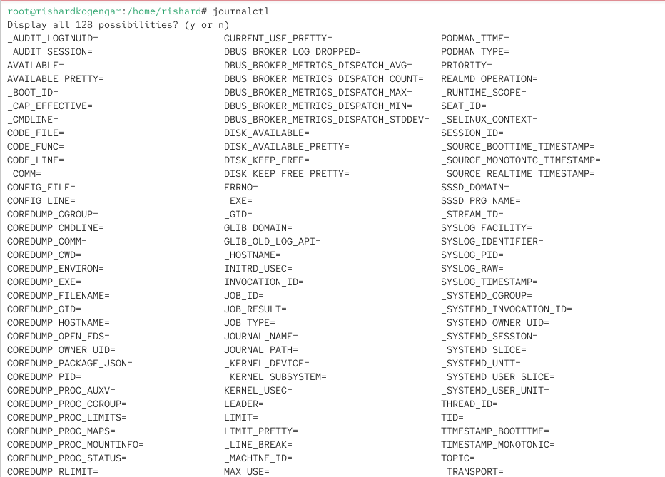

Поля фильтрации journalctl

## Фильтрация по UID 0

- Просмотрены события, относящиеся к UID=0
- В журнале видны системные действия суперпользователя и служб

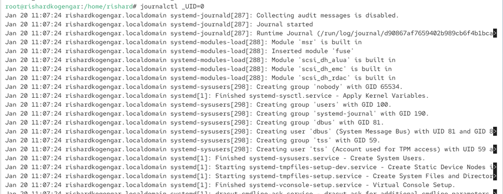

journalctl _UID=0

## Последние 20 строк журнала

- Выполнен вывод последних 20 сообщений журнала
- Удобно для быстрого анализа последних событий

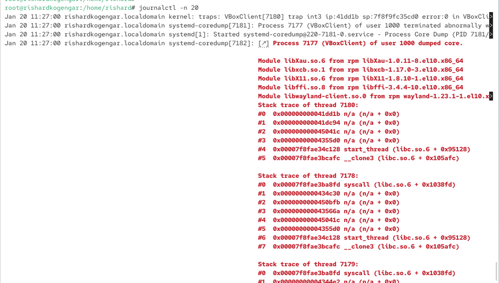

journalctl -n 20

## Сообщения только с ошибками

- Включена фильтрация по приоритету err
- Зафиксированы ошибки драйверов/служб и core dump процессов

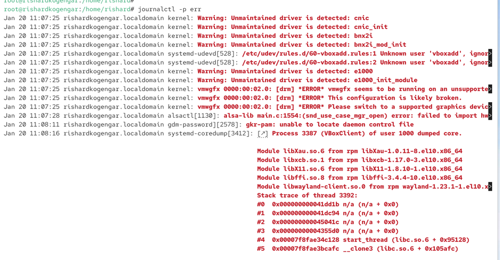

journalctl -p err

## Просмотр за период времени

- Выполнен просмотр сообщений, записанных со вчерашнего дня
- Использован параметр –since yesterday

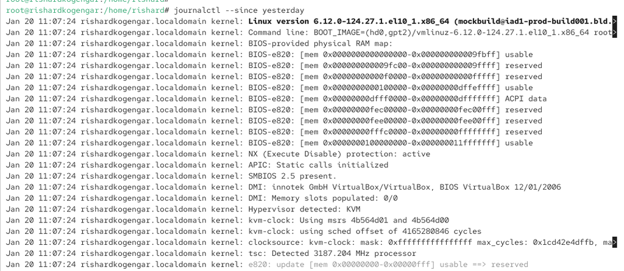

journalctl –since yesterday

## Ошибки за период времени

- Отображены только сообщения уровня err со вчерашнего дня
- Комбинация параметров –since и -p err

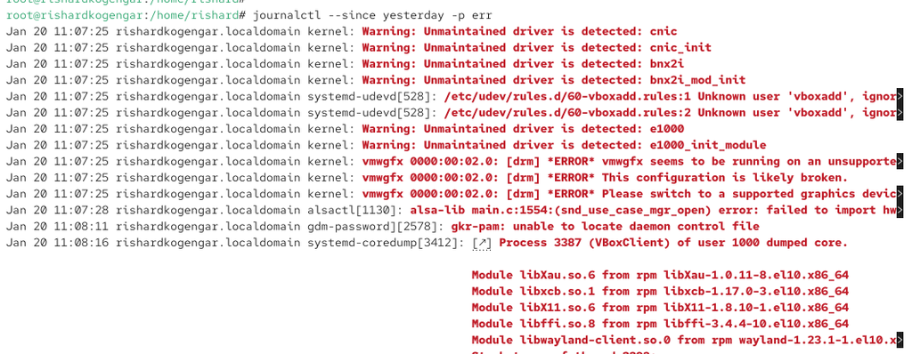

journalctl –since yesterday -p err

## Подробный вывод (verbose)

- Включён формат подробного вывода (-o verbose)
- Отображаются дополнительные поля события (BOOT_ID, TRANSPORT, PRIORITY и т.д.)

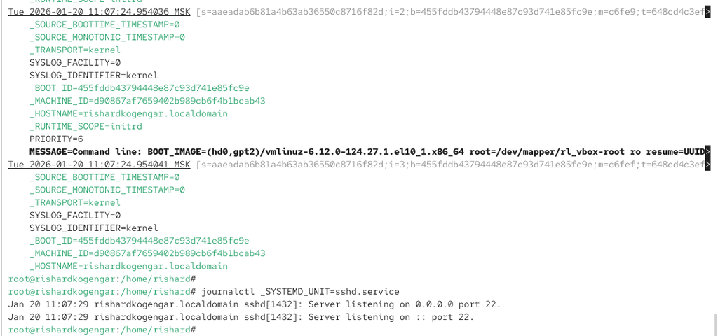

journalctl -o verbose

## Включение постоянного хранения

- Создан каталог /var/log/journal
- Назначены права: root:systemd-journal
- Установлены права доступа (режим 2755)
- Для применения изменений отправлен сигнал USR1 службе systemd-journald

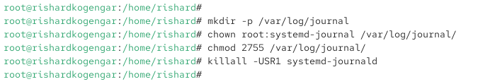

Создание /var/log/journal и применение изменений

# Итоги работы

## Вывод

- Освоен мониторинг системных событий и событий безопасности
- Настроено перенаправление логов Apache через syslog (local1)
- Создан отдельный отладочный журнал для *.debug
- Изучены ключевые режимы journalctl и фильтрация
- Включено постоянное хранение journald на диске